# IndividualFinalProject_BeatrizWahle

Beatriz Wahle

2024-11-21

```r
# All Libraries used in this file:
library(class)  # For KNN
library(caret)  # For Confusion Matrix
library(ggplot2) # For plotting graphics
library(kernlab) # For SVM
library(C50)
```

### Introduction

This Individual Final Project will consist of two main parts, a stacked model predictive modelling approach and an implementation of the prediction model. Before getting into an explanation to each, lets have an overview of the dataset.

**Dataset Overview: Telco Customer Churn**

The dataset analyzed is the Telco Customer Churn dataset, which contains information on 7,043 customers of a telecommunications company. The primary objective of this dataset is to predict customer churn, i.e., whether a customer will discontinue the service (Churn) based on various customer demographics, account information, and service usage metrics. The target variable Churn is a categorical variable with two levels: Yes (indicating churn) and No (indicating retention).

Regarding the structure of the data: the dataset includes 21 variables, which are a mix of categorical and numerical data types.

**Part 1: Stacked Model Predictive Modelling Approach**

In this first part of the project we will work with building different prediction models, for instance a Logistic Regression, a Support Vector Machine, and a KNN. Although it was already explained what Churn is, it is also important to grasp why it’s prediction matter.

Why Predict Churn?

- Financial Impact: Churn results in revenue loss for the company, and predictive insights can help in designing targeted retention campaigns, reducing costs associated with customer acquisition.
- Competitive Advantage: Minimizing churn ensures better customer retention compared to competitors in the telecommunications market.

Potential Users of the Predictive Model:

1. Marketing Teams: To design retention strategies such as targeted offers or loyalty programs for customers at high risk of churning.
2. Customer Support Departments: To proactively engage with at-risk customers and resolve their issues before they decide to leave.
3. Product Managers: To identify patterns in customer preferences and dissatisfaction, enabling them to improve products and services.
4. Senior Management/Executives: To evaluate the effectiveness of churn mitigation strategies and allocate resources more effectively.
5. Data Scientists/Analysts: To continuously improve and refine the predictive models, ensuring sustained performance as customer behaviors evolve.

### 1. Get the data

The first step before getting into the part 1 of building models is getting the dataset. This is what I an going to do in the following snippet. Apart from reading the csv file, the function `stringsAsFactors = T` will transform the string columns into factors, making it easier for processes on further steps.

```r
cust_data <- read.csv("TelcoChurn.csv", stringsAsFactors = T)
```

With the data loaded, lets look at its summary and structure before any pre-processing measures.

```r
summary(cust_data)
```

```
##       customerID      gender     SeniorCitizen    Partner    Dependents
##  0002-ORFBO:   1   Female:3488   Min.   :0.0000   No :3641   No :4933
##  0003-MKNFE:   1   Male  :3555   1st Qu.:0.0000   Yes:3402   Yes:2110
##  0004-TLHLJ:   1                 Median :0.0000
##  0011-IGKFF:   1                 Mean   :0.1621
##  0013-EXCHZ:   1                 3rd Qu.:0.0000
##  0013-MHZWF:   1                 Max.   :1.0000
##  (Other)   :7037
##      tenure      PhoneService          MultipleLines     InternetService
##  Min.   : 0.00   No : 682     No              :3390   DSL        :2421
##  1st Qu.: 9.00   Yes:6361     No phone service: 682   Fiber optic:3096
##  Median :29.00                Yes             :2971   No         :1526
##  Mean   :32.37
##  3rd Qu.:55.00
##  Max.   :72.00
##
##              OnlineSecurity              OnlineBackup
##  No                 :3498   No                 :3088
##  No internet service:1526   No internet service:1526
##  Yes                :2019   Yes                :2429
##
##
##
##
##             DeviceProtection              TechSupport
##  No                 :3095    No                 :3473
##  No internet service:1526    No internet service:1526
##  Yes                :2422    Yes                :2044
##
##
##
##
##               StreamingTV              StreamingMovies           Contract
##  No                 :2810   No                 :2785   Month-to-month:3875
##  No internet service:1526   No internet service:1526   One year      :1473
##  Yes                :2707   Yes                :2732   Two year      :1695
##
##
##
##
##  PaperlessBilling                   PaymentMethod  MonthlyCharges
##  No :2872         Bank transfer (automatic):1544   Min.   : 18.25
##  Yes:4171         Credit card (automatic)  :1522   1st Qu.: 35.50
##                   Electronic check         :2365   Median : 70.35
##                   Mailed check             :1612   Mean   : 64.76
##                                                    3rd Qu.: 89.85
##                                                    Max.   :118.75
##
##   TotalCharges    Churn
##  Min.   :  18.8   No :5174
##  1st Qu.: 401.4   Yes:1869
##  Median :1397.5
##  Mean   :2283.3
##  3rd Qu.:3794.7
##  Max.   :8684.8
##  NA's   :11
```

```r
str(cust_data)
```

```
## 'data.frame':    7043 obs. of  21 variables:
##  $ customerID      : Factor w/ 7043 levels "0002-ORFBO","0003-MKNFE",..: 5376 3963 2565 5536 6512 6552 1003 4771 5605 4535 ...
##  $ gender          : Factor w/ 2 levels "Female","Male": 1 2 2 2 1 1 2 1 1 2 ...
##  $ SeniorCitizen   : int  0 0 0 0 0 0 0 0 0 0 ...
##  $ Partner         : Factor w/ 2 levels "No","Yes": 2 1 1 1 1 1 1 1 2 1 ...
##  $ Dependents      : Factor w/ 2 levels "No","Yes": 1 1 1 1 1 1 2 1 1 2 ...
##  $ tenure          : int  1 34 2 45 2 8 22 10 28 62 ...
##  $ PhoneService    : Factor w/ 2 levels "No","Yes": 1 2 2 1 2 2 2 1 2 2 ...
##  $ MultipleLines   : Factor w/ 3 levels "No","No phone service",..: 2 1 1 2 1 3 3 2 3 1 ...
##  $ InternetService : Factor w/ 3 levels "DSL","Fiber optic",..: 1 1 1 1 2 2 2 1 2 1 ...
##  $ OnlineSecurity  : Factor w/ 3 levels "No","No internet service",..: 1 3 3 3 1 1 1 3 1 3 ...
##  $ OnlineBackup    : Factor w/ 3 levels "No","No internet service",..: 3 1 3 1 1 1 3 1 1 3 ...
##  $ DeviceProtection: Factor w/ 3 levels "No","No internet service",..: 1 3 1 3 1 3 1 1 3 1 ...
##  $ TechSupport     : Factor w/ 3 levels "No","No internet service",..: 1 1 1 3 1 1 1 1 3 1 ...
##  $ StreamingTV     : Factor w/ 3 levels "No","No internet service",..: 1 1 1 1 1 3 3 1 3 1 ...
##  $ StreamingMovies : Factor w/ 3 levels "No","No internet service",..: 1 1 1 1 1 3 1 1 3 1 ...
##  $ Contract        : Factor w/ 3 levels "Month-to-month",..: 1 2 1 2 1 1 1 1 1 2 ...
##  $ PaperlessBilling: Factor w/ 2 levels "No","Yes": 2 1 2 1 2 2 2 1 2 1 ...
##  $ PaymentMethod   : Factor w/ 4 levels "Bank transfer (automatic)",..: 3 4 4 1 3 3 2 4 3 1 ...
##  $ MonthlyCharges  : num  29.9 57 53.9 42.3 70.7 ...
##  $ TotalCharges    : num  29.9 1889.5 108.2 1840.8 151.7 ...
##  $ Churn           : Factor w/ 2 levels "No","Yes": 1 1 2 1 2 2 1 1 2 1 ...
```

### 2. Clean the data

Once we have the data, it is always fundamental to check for missing values. The code below will count the total of missing values (if any).

```r
missing_values <- sum(is.na(cust_data))
```

The dataset has 11 missing values and we need to handle those. Let’s look at which columns have missing values:

```r
data.frame(colSums(is.na(cust_data)))
```

```
##                  colSums.is.na.cust_data..
## customerID                               0
## gender                                   0
## SeniorCitizen                            0
## Partner                                  0
## Dependents                               0
## tenure                                   0
## PhoneService                             0
## MultipleLines                            0
## InternetService                          0
## OnlineSecurity                           0
## OnlineBackup                             0
## DeviceProtection                         0
## TechSupport                              0
## StreamingTV                              0
## StreamingMovies                          0
## Contract                                 0
## PaperlessBilling                         0
## PaymentMethod                            0
## MonthlyCharges                           0
## TotalCharges                            11
## Churn                                    0
```

As we can see, the only column with missing values is the `TotalCharges`. Since it is a numeric column, we could input the mean or the median on those missing values, however, that can introduce a small bias. As there are only 11 rows out of the 7043 observations, that shouldn’t justify the exclusion of the entire column. I will choose to simply delete those rows.

```r
cust_data <- na.omit(cust_data)

# Check there are no missing values
sum(is.na(cust_data))
```

```
## [1] 0
```

Now that we do not have any missing values, we can move on to the next steps of pre-processing.

**Deleting meaningless columns:**

The column `customerID` should not aggregate value to the prediction models and therefore will be deleted.

```r
cust_data$customerID <- NULL
```

If we look back to the data structure, we can see that the target column `Churn` is a factor with two levels. These are coded as 1 and 2 (as counting in R starts on 1, differently than Python or other languages that counting starts in 0). Simply for a personal choice of formality (to maintain the positive class as 1), I will transform the factors into a numeric column of 0, 1.

```r
str(cust_data$Churn)
```

```
##  Factor w/ 2 levels "No","Yes": 1 1 2 1 2 2 1 1 2 1 ...
```

```r
cust_data$Churn <- ifelse(cust_data$Churn == "No", 0, 1)
```

**Encoding/Creating Dummies:**

I now convert the original dataset into one that represents each factor/level within a column into it’s own separate column (dummies/one-hot encoding). For example, `InternetService` turns into `InternetServiceFiber optic`, and `InternetServiceNo`. One thing to note is that the model matrix line drops one of the columns for each factor, as to avoid multicolinearity; this was not the case for the gender column. Likely due to the inconsistent formatting of the name of the levels of that variable, our model.matrix line wouldn’t drop a column, so I manually dropped one.

```r
encoded_data <- as.data.frame(model.matrix( ~ . - 1, data = cust_data))
encoded_data$genderMale <- NULL

# Just to ensure the structure
str(encoded_data)
```

```
## 'data.frame':    7032 obs. of  31 variables:
##  $ genderFemale                        : num  1 0 0 0 1 1 0 1 1 0 ...
##  $ SeniorCitizen                       : num  0 0 0 0 0 0 0 0 0 0 ...
##  $ PartnerYes                          : num  1 0 0 0 0 0 0 0 1 0 ...
##  $ DependentsYes                       : num  0 0 0 0 0 0 1 0 0 1 ...
##  $ tenure                              : num  1 34 2 45 2 8 22 10 28 62 ...
##  $ PhoneServiceYes                     : num  0 1 1 0 1 1 1 0 1 1 ...
##  $ MultipleLinesNo phone service       : num  1 0 0 1 0 0 0 1 0 0 ...
##  $ MultipleLinesYes                    : num  0 0 0 0 0 1 1 0 1 0 ...
##  $ InternetServiceFiber optic          : num  0 0 0 0 1 1 1 0 1 0 ...
##  $ InternetServiceNo                   : num  0 0 0 0 0 0 0 0 0 0 ...
##  $ OnlineSecurityNo internet service   : num  0 0 0 0 0 0 0 0 0 0 ...
##  $ OnlineSecurityYes                   : num  0 1 1 1 0 0 0 1 0 1 ...
##  $ OnlineBackupNo internet service     : num  0 0 0 0 0 0 0 0 0 0 ...
##  $ OnlineBackupYes                     : num  1 0 1 0 0 0 1 0 0 1 ...
```

[output cut: 17 more lines]

**Scaling:**

Another important step of pre-processing is scaling the numerical variables of the data. Further on in this code, I will build a KNN model; for it, the numeric factors have to be comparable to one another. For this to happen, they have to be on the same scale, so I create a new dataframe that contains scaled data for the KNN model. I utilize min-max scaling in this instance, so each numeric variable is now on a scale of 0-1.

```r
# Formual for scaling
minmax <- function(x) {
  (x - min(x)) / (max(x)-min(x))
}

scaled_data <- as.data.frame(lapply(encoded_data, minmax))
```

**Balancing/Oversampling:**

Another possible step before splitting the data and building the models is balancing the rows in regards to the target variable. On very imbalanced datasets, some models tend to favor the majority class, resulting in poor performance on the minority class. So first, lets look at the current distribution/balance of the Churn column.

```r
table(scaled_data$Churn)
```

```
##
##    0    1
## 5163 1869
```

```r
positive_percentage <- ((sum(scaled_data$Churn))/(sum(nrow(scaled_data))))*100
```

The dataset has a 26.58% proportion of positive outcomes, indicating a moderate class imbalance. Considering that one of the primary goals is to build a stacked model, which requires maintaining the same number of rows across all datasets used for individual models, this means that either oversampling must be applied to all models, or none.

While balancing the dataset can enhance the performance of some models, such as Logistic Regression and K-Nearest Neighbors (KNN), it can introduce redundancy and negatively impact the performance of others, such as Support Vector Machines (SVM), Decision Trees, and Random Forests, particularly when applied to new data. Given these considerations, and the fact that the level of imbalance is not severe, I have decided not to balance the dataset to preserve its original structure and ensure consistency across all models.

### 3. Split the data

The final step before getting into the part of building the models (Part 1) is splitting the dataset into train and test.

1. Logistic Regression: encoded data. It’s important not to use scaled data for Logistic Regression because scaling reduce variance in the dataset, which is crucial for Logistic Regression to perform accurately.
2. KNN: scaled data. We should scale data for a KNN model because it relies on distance metrics (e.g., Euclidean distance), and unscaled features with larger ranges can disproportionately influence the model’s predictions, leading to biased results.
3. SVM: scaled data. Support Vector Machine models also need the factors to be encoded. Above that you should generally scale your data before using a SVM algorithm because they are sensitive to the scale of features, meaning features with larger values will have a disproportionate influence on the decision boundary, so scaling ensures all features contribute equally to the classification process.

```r
test_rate <- 0.5
set.seed(666)
test_rows <- sample(1:nrow(cust_data), test_rate*nrow(cust_data))

cust_encoded_test <- encoded_data[test_rows, ]
cust_encoded_train <- encoded_data[-test_rows, ]

cust_scaled_test <- scaled_data[test_rows, ]
cust_scaled_train <- scaled_data[-test_rows, ]
```

## Part 1: Stacked Model Predictive Modelling Approach

**Logistic Regression:**

As I want for the prediction to be binary, I created an `ifelse` in which every prediction below 0.3 is considered to be failed (0), and from 0.3 up successful (1). The threshold was decided to be 0.3 because after some manual iterations (e.g. 0.2, 0.25, 0.4, 0.5), this was the one to better balance the metrics of accuracy, sensitivity and specificity.

```r
lr <- glm(Churn ~ ., data = cust_encoded_train, family = binomial)
stepwise_lr <- step(lr, direction = "both", trace = 0)

prediction_lr <- predict(stepwise_lr, cust_encoded_test, type = "response")
binary_prediction_lr <- ifelse(prediction_lr < 0.3, 0, 1)

confusionMatrix(as.factor(binary_prediction_lr),
                as.factor(cust_encoded_test$Churn),
                positive = "1")
```

```
## Confusion Matrix and Statistics
##
##           Reference
## Prediction    0    1
##          0 1977  226
##          1  624  689
##
##                Accuracy : 0.7582
##                  95% CI : (0.7437, 0.7723)
##     No Information Rate : 0.7398
##     P-Value [Acc > NIR] : 0.006287
##
##                   Kappa : 0.4497
##
##  Mcnemar's Test P-Value : < 2.2e-16
##
##             Sensitivity : 0.7530
##             Specificity : 0.7601
##          Pos Pred Value : 0.5248
##          Neg Pred Value : 0.8974
##              Prevalence : 0.2602
##          Detection Rate : 0.1960
##    Detection Prevalence : 0.3734
##       Balanced Accuracy : 0.7565
##
##        'Positive' Class : 1
##
```

The logistic regression model achieves an accuracy of 75.82%, which is good, with a moderate Kappa value of 0.4497, indicating fair agreement beyond chance. Sensitivity, at 75.30%, shows the model effectively identifies most churners but still misses about a quarter, which could impact retention strategies.

**Support Vector Machine:**

A Support Vector Machine (SVM) predicts by finding the optimal hyper-plane or boundary that maximally separates data points of different classes in a high-dimensional space, using support vectors (critical data points) to define this margin.

Here, we were requested to test out 3 different kernels, and find out which performs the best for our dataset. There are two ways to do so: (1) manually testing out all of the kernels or (2) having a function that loops over the kernels and gather the most important values to compare them (Accuracy, Kappa and Sensitivity).

Although both codes are demonstrated below, I chose to use the function simply because the visualization of all the metrics of the 3 kernels together makes it easier for comparison.

```r
set.seed(666)
try_kernels <- function(kernel_name) {
  model <- ksvm(as.factor(Churn) ~ ., data = cust_scaled_train, kernel = kernel_name)
  predictions <- predict(model, cust_scaled_test)
  cm <- confusionMatrix(as.factor(predictions), as.factor(cust_scaled_test$Churn), positive = "1")

  accuracy <- cm$overall["Accuracy"]
  kappa <- cm$overall["Kappa"]
  sensitivity <- cm$byClass["Sensitivity"]

  # Return all metrics
  return(c(accuracy = accuracy, kappa = kappa, sensitivity = sensitivity))
}


kernels <- c("vanilladot", "polydot", "rbfdot")
data.frame(sapply(kernels, try_kernels))
```

```
##                         vanilladot   polydot    rbfdot
## accuracy.Accuracy        0.7980660 0.7980660 0.7989192
## kappa.Kappa              0.4550758 0.4550758 0.4359985
## sensitivity.Sensitivity  0.5540984 0.5540984 0.4994536
```

```r
svm <- ksvm(as.factor(Churn) ~ ., data = cust_scaled_train,
                          kernel = "polydot")
svm_prediction <- predict(svm, cust_scaled_test)
confusionMatrix(as.factor(svm_prediction),
                as.factor(cust_scaled_test$Churn),
                positive="1")
```

```
## Confusion Matrix and Statistics
##
##           Reference
## Prediction    0    1
##          0 2299  408
##          1  302  507
##
##                Accuracy : 0.7981
##                  95% CI : (0.7844, 0.8112)
##     No Information Rate : 0.7398
##     P-Value [Acc > NIR] : 3.436e-16
##
##                   Kappa : 0.4551
##
##  Mcnemar's Test P-Value : 8.128e-05
##
##             Sensitivity : 0.5541
##             Specificity : 0.8839
##          Pos Pred Value : 0.6267
##          Neg Pred Value : 0.8493
##              Prevalence : 0.2602
##          Detection Rate : 0.1442
##    Detection Prevalence : 0.2301
##       Balanced Accuracy : 0.7190
##
##        'Positive' Class : 1
##
```

```r
#svm2 <- ksvm(as.factor(Churn) ~ ., data = cust_scaled_train,
#                          kernel = "vanilladot")
#svm_prediction2 <- predict(svm2, cust_scaled_test)
#confusionMatrix(as.factor(svm_prediction2),
#                as.factor(cust_scaled_test$Churn),
#                positive="1")
#
#svm3 <- ksvm(as.factor(Churn) ~ ., data = cust_scaled_train,
#                          kernel = "rbfdot")
#svm_prediction3 <- predict(svm3, cust_scaled_test)
#confusionMatrix(as.factor(svm_prediction3),
#                as.factor(cust_scaled_test$Churn),
#                positive="1")
```

Based on the information provided we can conclude that:

Conclusion: The **vanilla** kernel or **polynomial** kernel best fits the data due to their higher Kappa and sensitivity, making them more effective for churn prediction.

Regarding the performance of the best model chosen, the SVM model using the “polydot” kernel achieves an accuracy of 79.81%, which is a noticeable improvement over the Logistic Regression. The Kappa statistic (0.4551) reflects moderate agreement beyond random chance, comparable to other models evaluated. However, the sensitivity (55.41%), still leaves room for improvement in identifying churners effectively. The high specificity (88.39%) shows the model is better at predicting non-churners, but a more balanced sensitivity would enhance its effectiveness for churn prediction tasks.

**K-Nearest Neighbors:**

Next, I developed a K-Nearest Neighbors model, another predictive model. KNN creates predictions by examining a data point’s k nearest neighbors (k being a number we decide upon). A data point’s nearest neighbors would be ones that are most similar to it based on the predictive variables.

In order to choose the k in which the model performs best, I developed a function that will run through ks from 1 to 20 to give me each Accuracy, Kappa, and Sensitivity. Then, I will plot it so I can look for the optimal K. (The code here is hidden due to its length)

```
##             k  Accuracy     Kappa Sensitivity
## Accuracy    1 0.7272469 0.3141958   0.5267760
## Accuracy1   2 0.7147327 0.2876161   0.5136612
## Accuracy2   3 0.7536974 0.3561967   0.5169399
## Accuracy3   4 0.7542662 0.3617789   0.5278689
## Accuracy4   5 0.7585324 0.3677079   0.5234973
## Accuracy5   6 0.7585324 0.3672559   0.5224044
## Accuracy6   7 0.7718999 0.4012142   0.5453552
## Accuracy7   8 0.7653584 0.3829374   0.5300546
## Accuracy8   9 0.7718999 0.4016427   0.5464481
## Accuracy9  10 0.7713311 0.3988601   0.5420765
## Accuracy10 11 0.7690557 0.3880517   0.5256831
## Accuracy11 12 0.7693402 0.3929734   0.5366120
## Accuracy12 13 0.7716155 0.3993924   0.5420765
## Accuracy13 14 0.7764505 0.4110515   0.5486339
## Accuracy14 15 0.7736064 0.4031296   0.5420765
## Accuracy15 16 0.7704778 0.3964006   0.5398907
## Accuracy16 17 0.7755973 0.4119728   0.5551913
## Accuracy17 18 0.7724687 0.4048382   0.5519126
## Accuracy18 19 0.7750284 0.4113238   0.5562842
## Accuracy19 20 0.7738908 0.4091903   0.5562842
```

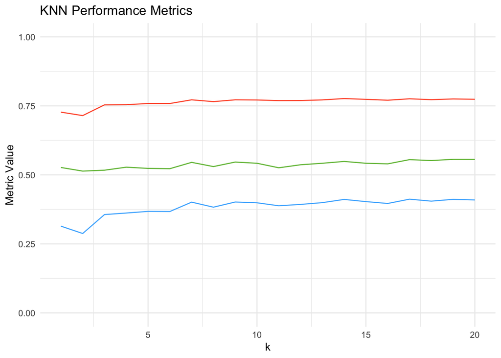

Selecting **k = 19** ensures robust performance across all metrics while avoiding overfitting at smaller k values or underfitting at larger ones.

```r
churn_col <- which(colnames(cust_scaled_train) == "Churn")
prediction_knn <- knn(train = cust_scaled_train[,-churn_col],
                      test = cust_scaled_test[,-churn_col],
                      cl = cust_scaled_train[,churn_col],
                      k = 19)
summary(prediction_knn)
```

```
##    0    1
## 2622  894
```

```r
confusionMatrix(as.factor(prediction_knn), as.factor(cust_scaled_test$Churn), positive = "1")
```

```
## Confusion Matrix and Statistics
##
##           Reference
## Prediction    0    1
##          0 2216  406
##          1  385  509
##
##                Accuracy : 0.775
##                  95% CI : (0.7609, 0.7887)
##     No Information Rate : 0.7398
##     P-Value [Acc > NIR] : 7.238e-07
##
##                   Kappa : 0.4113
##
##  Mcnemar's Test P-Value : 0.477
##
##             Sensitivity : 0.5563
##             Specificity : 0.8520
##          Pos Pred Value : 0.5694
##          Neg Pred Value : 0.8452
##              Prevalence : 0.2602
##          Detection Rate : 0.1448
##    Detection Prevalence : 0.2543
##       Balanced Accuracy : 0.7041
##
##        'Positive' Class : 1
##
```

The KNN model achieves an accuracy of 77.5%, which is better than the Logistic Regression but worse than the SVM, indicating reasonable predictive performance. The Kappa statistic (0.4113) reflects the worse agreement beyond chance, although not being incredibly bad. However, the sensitivity (55.63%) is relatively low if compared to the Logistic Regression, meaning the model struggles to identify churners effectively, which could limit its usefulness in retention strategies. While the specificity (85.20%) indicates strong performance in predicting non-churners, improving sensitivity is crucial to better capture at-risk customers.

**Second Level Decision Tree:**

Now with all three models built, I will create a second-level (stack) decision tree to combine their predictions, leveraging the strengths of each model to improve overall accuracy by using their outputs as features to make the final classification decision.

The first thing to do is to combine all predictions into a new dataframe, as done with the code below:

```r
# Renaming the original target variable from the test set:
response <- cust_encoded_test$Churn

all_predictions <- data.frame(
                              binary_prediction_lr = as.numeric(binary_prediction_lr),
                              prediction_knn = as.numeric(prediction_knn),
                              svm_prediction = as.numeric(svm_prediction),
                              response = as.numeric(response))

str(all_predictions)
```

```
## 'data.frame':    3516 obs. of  4 variables:
##  $ binary_prediction_lr: num  1 1 0 0 0 0 0 0 0 1 ...
##  $ prediction_knn      : num  2 2 1 1 1 1 1 1 1 2 ...
##  $ svm_prediction      : num  2 2 1 1 1 1 1 1 1 2 ...
##  $ response            : num  1 0 1 0 0 0 0 1 0 1 ...
```

```r
# Just a formality to make sure all positives are = 1
all_predictions$prediction_knn <- ifelse(all_predictions$prediction_knn == 1, 0, 1)
all_predictions$svm_prediction <- ifelse(all_predictions$svm_prediction == 1, 0, 1)
```

With the dataset create, and correctly formatted, we can split it to apply the Decision Tree. That’s what the code below does:

```r
test_rate <- 0.3
set.seed(1234567)

test_prediction_rows <- sample(1:nrow(all_predictions), test_rate*nrow(all_predictions))
train_predictions <- all_predictions[-test_prediction_rows, ]
test_predictions <- all_predictions[test_prediction_rows, ]
```

Once with the splits we apply a simple decision tree.

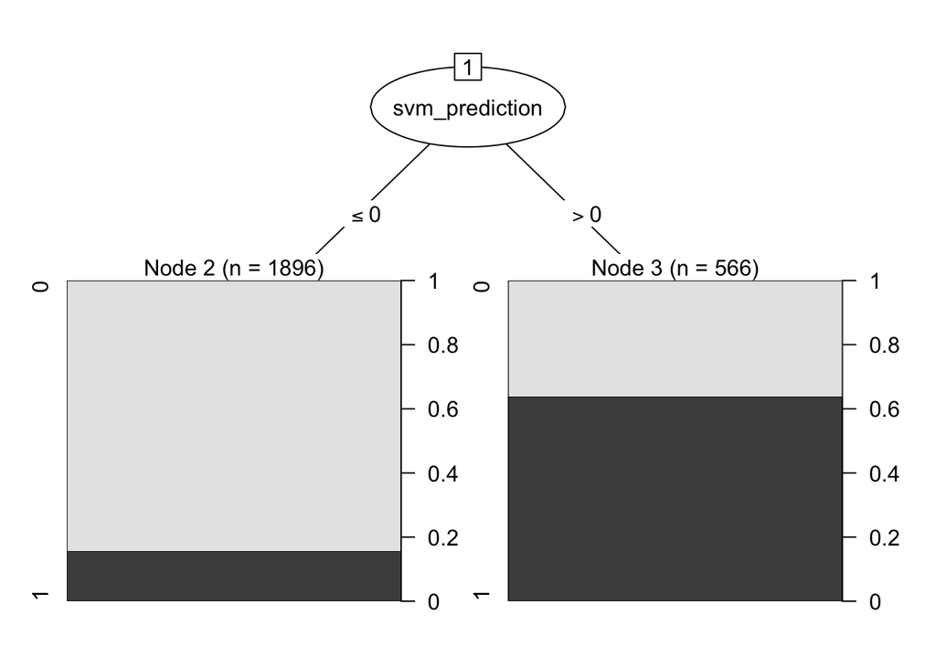

```r
model <- C5.0(as.factor(response) ~ ., data = train_predictions)
plot(model)
```

```r
predictions <- predict(model, newdata = test_predictions)

confusionMatrix(as.factor(predictions),
                as.factor(test_predictions$response),
                positive="1")
```

```
## Confusion Matrix and Statistics
##
##           Reference
## Prediction   0   1
##          0 700 111
##          1  97 146
##
##                Accuracy : 0.8027
##                  95% CI : (0.7773, 0.8263)
##     No Information Rate : 0.7562
##     P-Value [Acc > NIR] : 0.0001892
##
##                   Kappa : 0.4548
##
##  Mcnemar's Test P-Value : 0.3673822
##
##             Sensitivity : 0.5681
##             Specificity : 0.8783
##          Pos Pred Value : 0.6008
##          Neg Pred Value : 0.8631
##              Prevalence : 0.2438
##          Detection Rate : 0.1385
##    Detection Prevalence : 0.2306
##       Balanced Accuracy : 0.7232
##
##        'Positive' Class : 1
##
```

From the metrics of this simple decision tree model we can see that although the accuracy is really high, the sensitivity is considerably low if compared to some of the individual models. To try to solve that and better balance the accuracy/sensitivity trade-off, I will apply a cost matrix that penalizes the false negatives, which will increase the false positives, but likely, the true positives as well.

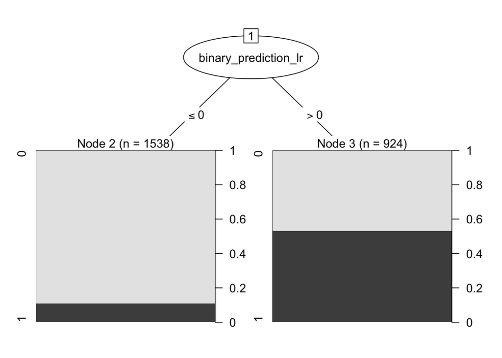

```r
cost_matrix_prediction <- matrix(c(0, 3,
                                  1, 0),
                                  nrow = 2,
                                  byrow = TRUE)
rownames(cost_matrix_prediction) <- colnames(cost_matrix_prediction) <- c(0, 1)

model2 <- C5.0(as.factor(response) ~ ., data = train_predictions, costs = cost_matrix_prediction)
plot(model2)
```

```r
predictions2 <- predict(model2, newdata = test_predictions)

confusionMatrix(as.factor(predictions2),
                as.factor(test_predictions$response),
                positive="1")
```

```
## Confusion Matrix and Statistics
##
##           Reference
## Prediction   0   1
##          0 605  60
##          1 192 197
##
##                Accuracy : 0.7609
##                  95% CI : (0.734, 0.7864)
##     No Information Rate : 0.7562
##     P-Value [Acc > NIR] : 0.3755
##
##                   Kappa : 0.4477
##
##  Mcnemar's Test P-Value : <2e-16
##
##             Sensitivity : 0.7665
##             Specificity : 0.7591
##          Pos Pred Value : 0.5064
##          Neg Pred Value : 0.9098
##              Prevalence : 0.2438
##          Detection Rate : 0.1869
##    Detection Prevalence : 0.3691
##       Balanced Accuracy : 0.7628
##
##        'Positive' Class : 1
##
```

In general, the stack model makes a good job at being consistent across the metrics.